# German_Credit_Scoring

2024-01-14

##### SARAN THAWORN

Trainig models base on Caret library (Classification and Regression Training) with R language

## I. Get Data

Data for this credit scoring case

```r
# libraries
library(caret)
library(tidyverse)
library(mlbench)
library(dplyr)
library(ggplot2)

# I. get data
df <- read.csv("index.csv")
str(df)
```

```
## 'data.frame':    1000 obs. of  21 variables:
##  $ Creditability                    : int  1 1 1 1 1 1 1 1 1 1 ...
##  $ Account.Balance                  : int  1 1 2 1 1 1 1 1 4 2 ...
##  $ Duration.of.Credit..month.       : int  18 9 12 12 12 10 8 6 18 24 ...
##  $ Payment.Status.of.Previous.Credit: int  4 4 2 4 4 4 4 4 4 2 ...
##  $ Purpose                          : int  2 0 9 0 0 0 0 0 3 3 ...
##  $ Credit.Amount                    : int  1049 2799 841 2122 2171 2241 3398 1361 1098 3758 ...
##  $ Value.Savings.Stocks             : int  1 1 2 1 1 1 1 1 1 3 ...
##  $ Length.of.current.employment     : int  2 3 4 3 3 2 4 2 1 1 ...
##  $ Instalment.per.cent              : int  4 2 2 3 4 1 1 2 4 1 ...
##  $ Sex...Marital.Status             : int  2 3 2 3 3 3 3 3 2 2 ...
##  $ Guarantors                       : int  1 1 1 1 1 1 1 1 1 1 ...
##  $ Duration.in.Current.address      : int  4 2 4 2 4 3 4 4 4 4 ...
##  $ Most.valuable.available.asset    : int  2 1 1 1 2 1 1 1 3 4 ...
##  $ Age..years.                      : int  21 36 23 39 38 48 39 40 65 23 ...
##  $ Concurrent.Credits               : int  3 3 3 3 1 3 3 3 3 3 ...
##  $ Type.of.apartment                : int  1 1 1 1 2 1 2 2 2 1 ...
##  $ No.of.Credits.at.this.Bank       : int  1 2 1 2 2 2 2 1 2 1 ...
##  $ Occupation                       : int  3 3 2 2 2 2 2 2 1 1 ...
##  $ No.of.dependents                 : int  1 2 1 2 1 2 1 2 1 1 ...
##  $ Telephone                        : int  1 1 1 1 1 1 1 1 1 1 ...
##  $ Foreign.Worker                   : int  1 1 1 2 2 2 2 2 1 1 ...
```

Here is the German Credit Datasets and the structure of datasets. It’s have 21 Variables and 1000 obs.

$$\\[1in]$$

## II. Exploratory Data Analysis (EDA) and pre process

Creating marginal proportional tables from a K1 x K2 x K3 x … x Kl contingency table.

Marginal proportion tables:

```r
attach(df) # When the data frame isattached then the colnames will be directly call

# Marginal proportion of first 8 - levels contingency table
margin.table(prop.table(table(Account.Balance,
                              Payment.Status.of.Previous.Credit,
                              Duration.of.Credit..month.,
                              Value.Savings.Stocks,
                              Length.of.current.employment,
                              Instalment.per.cent,
                              Occupation,
                              Sex...Marital.Status)),1)
```

```
## Account.Balance
##     1     2     3     4
## 0.274 0.269 0.063 0.394
```

```r
# Marginal proportion of last 8 - levels contingency table
margin.table(prop.table(table(Duration.in.Current.address,
                              Type.of.apartment,
                              Most.valuable.available.asset,
                              No.of.Credits.at.this.Bank,
                              Guarantors,
                              Concurrent.Credits,
                              No.of.dependents,
                              Telephone,
                              Foreign.Worker)),1)
```

```
## Duration.in.Current.address
##     1     2     3     4
## 0.130 0.308 0.149 0.413
```

```r
# Marginal proportion of purpose
margin.table(prop.table(table(df$Purpose)),1)
```

```
##
##     0     1     2     3     4     5     6     8     9    10
## 0.234 0.103 0.181 0.280 0.012 0.022 0.050 0.009 0.097 0.012
```

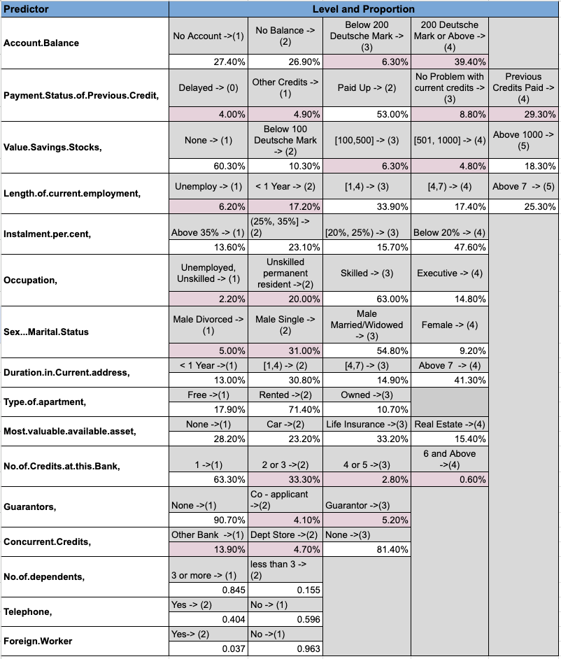

```r
# All variables in marginal proportion table
knitr::include_graphics("/Users/saranthaworn/Table1.png")
```

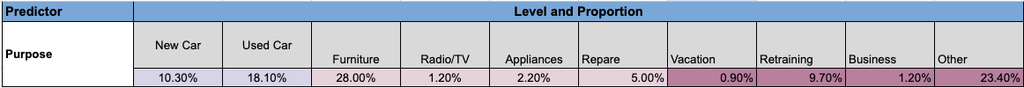

```r
knitr::include_graphics("/Users/saranthaworn/Table2.png")
```

The pink shadings indicate that these levels have too few observations and the levels are merged for final analysis.

#### The final classification for the predictors that may potentially have any influence on Creditability.

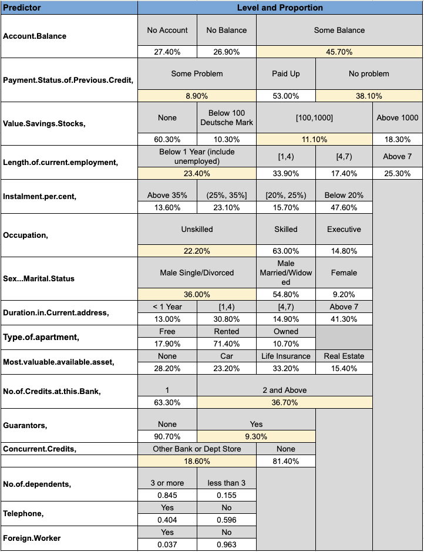

```r
knitr::include_graphics("/Users/saranthaworn/Table3.png")
```

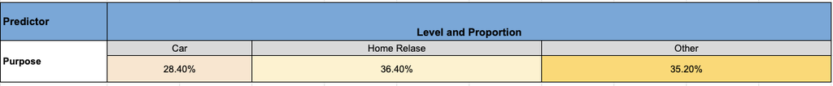

```r
knitr::include_graphics("/Users/saranthaworn/Table4.png")
```

$$\\[1in]$$

#### Visualize the clean data frame

```r
# read clean data frame
clean_df <- read.csv("Clean_index.csv")

# structure of data frame
str(clean_df)
```

```
## 'data.frame':    1000 obs. of  21 variables:
##  $ Creditability                    : int  1 1 1 1 1 1 1 1 1 1 ...
##  $ Account.Balance                  : int  1 1 2 1 1 1 1 1 3 2 ...
##  $ Duration.of.Credit..month.       : int  18 9 12 12 12 10 8 6 18 24 ...
##  $ Payment.Status.of.Previous.Credit: int  3 3 2 3 3 3 3 3 3 2 ...
##  $ Purpose                          : int  1 3 3 3 3 3 3 3 2 2 ...
##  $ Credit.Amount                    : int  1049 2799 841 2122 2171 2241 3398 1361 1098 3758 ...
##  $ Value.Savings.Stocks             : int  1 1 2 1 1 1 1 1 1 3 ...
##  $ Length.of.current.employment     : int  1 2 3 2 2 1 3 1 1 1 ...
##  $ Instalment.per.cent              : int  4 2 2 3 4 1 1 2 4 1 ...
##  $ Sex...Marital.Status             : int  1 2 1 2 2 2 2 2 1 1 ...
##  $ Guarantors                       : int  1 1 1 1 1 1 1 1 1 1 ...
##  $ Duration.in.Current.address      : int  4 2 4 2 4 3 4 4 4 4 ...
##  $ Most.valuable.available.asset    : int  2 1 1 1 2 1 1 1 3 4 ...
##  $ Age..years.                      : int  21 36 23 39 38 48 39 40 65 23 ...
##  $ Concurrent.Credits               : int  2 2 2 2 1 2 2 2 2 2 ...
##  $ Type.of.apartment                : int  1 1 1 1 2 1 2 2 2 1 ...
##  $ No.of.Credits.at.this.Bank       : int  1 2 1 2 2 2 2 1 2 1 ...
##  $ Occupation                       : int  2 2 1 1 1 1 1 1 1 1 ...
##  $ No.of.dependents                 : int  1 2 1 2 1 2 1 2 1 1 ...
##  $ Telephone                        : int  1 1 1 1 1 1 1 1 1 1 ...
##  $ Foreign.Worker                   : int  1 1 1 2 2 2 2 2 1 1 ...
```

Cross-tabulation of the 12 predictors as defined above with Creditability is shown below.

```r
library(janitor)
library(knitr)
library(kableExtra)
#Cross Tables of Discrete Variables
CrossTable_1 <-clean_df %>%
  tabyl(Creditability, Account.Balance) %>%
  adorn_totals( where = c("row", "col") ) %>%
  adorn_percentages("col") %>%
  adorn_pct_formatting() %>%
  adorn_ns( position = "front" ) %>%
  adorn_title(placement = "top")

CrossTable_2 <-clean_df %>%
  tabyl(Creditability, Payment.Status.of.Previous.Credit) %>%
  adorn_totals( where = c("row", "col") ) %>%
  adorn_percentages("col") %>%
  adorn_pct_formatting() %>%
  adorn_ns( position = "front" ) %>%
  adorn_title(placement = "top")
```

|  | Account.Balance |  |  |  |
| --- | --- | --- | --- | --- |
| Creditability | 1 | 2 | 3 | Total |
| 0 | 135 (49.3%) | 105 (39.0%) | 60 (13.1%) | 300 (30.0%) |
| 1 | 139 (50.7%) | 164 (61.0%) | 397 (86.9%) | 700 (70.0%) |
| Total | 274 (100.0%) | 269 (100.0%) | 457 (100.0%) | 1,000 (100.0%) |

|  | Payment.Status.of.Previous.Credit |  |  |  |
| --- | --- | --- | --- | --- |
| Creditability | 1 | 2 | 3 | Total |
| 0 | 53 (59.6%) | 169 (31.9%) | 78 (20.5%) | 300 (30.0%) |
| 1 | 36 (40.4%) | 361 (68.1%) | 303 (79.5%) | 700 (70.0%) |
| Total | 89 (100.0%) | 530 (100.0%) | 381 (100.0%) | 1,000 (100.0%) |

|  | Value.Savings.Stocks |  |  |  |  |
| --- | --- | --- | --- | --- | --- |
| Creditability | 1 | 2 | 3 | 4 | Total |
| 0 | 217 (36.0%) | 34 (33.0%) | 17 (15.3%) | 32 (17.5%) | 300 (30.0%) |
| 1 | 386 (64.0%) | 69 (67.0%) | 94 (84.7%) | 151 (82.5%) | 700 (70.0%) |
| Total | 603 (100.0%) | 103 (100.0%) | 111 (100.0%) | 183 (100.0%) | 1,000 (100.0%) |

|  | Length.of.current.employment |  |  |  |  |
| --- | --- | --- | --- | --- | --- |
| Creditability | 1 | 2 | 3 | 4 | Total |
| 0 | 93 (39.7%) | 104 (30.7%) | 39 (22.4%) | 64 (25.3%) | 300 (30.0%) |
| 1 | 141 (60.3%) | 235 (69.3%) | 135 (77.6%) | 189 (74.7%) | 700 (70.0%) |
| Total | 234 (100.0%) | 339 (100.0%) | 174 (100.0%) | 253 (100.0%) | 1,000 (100.0%) |

|  | Sex…Marital.Status |  |  |  |
| --- | --- | --- | --- | --- |
| Creditability | 1 | 2 | 3 | Total |
| 0 | 129 (35.8%) | 146 (26.6%) | 25 (27.2%) | 300 (30.0%) |
| 1 | 231 (64.2%) | 402 (73.4%) | 67 (72.8%) | 700 (70.0%) |
| Total | 360 (100.0%) | 548 (100.0%) | 92 (100.0%) | 1,000 (100.0%) |

|  | No.of.Credits.at.this.Bank |  |  |
| --- | --- | --- | --- |
| Creditability | 1 | 2 | Total |
| 0 | 200 (31.6%) | 100 (27.2%) | 300 (30.0%) |
| 1 | 433 (68.4%) | 267 (72.8%) | 700 (70.0%) |
| Total | 633 (100.0%) | 367 (100.0%) | 1,000 (100.0%) |

|  | Guarantors |  |  |
| --- | --- | --- | --- |
| Creditability | 1 | 2 | Total |
| 0 | 272 (30.0%) | 28 (30.1%) | 300 (30.0%) |
| 1 | 635 (70.0%) | 65 (69.9%) | 700 (70.0%) |
| Total | 907 (100.0%) | 93 (100.0%) | 1,000 (100.0%) |

|  | Concurrent.Credits |  |  |
| --- | --- | --- | --- |
| Creditability | 1 | 2 | Total |
| 0 | 76 (40.9%) | 224 (27.5%) | 300 (30.0%) |
| 1 | 110 (59.1%) | 590 (72.5%) | 700 (70.0%) |
| Total | 186 (100.0%) | 814 (100.0%) | 1,000 (100.0%) |

|  | Type.of.apartment |  |  |  |
| --- | --- | --- | --- | --- |
| Creditability | 1 | 2 | 3 | Total |
| 0 | 70 (39.1%) | 186 (26.1%) | 44 (41.1%) | 300 (30.0%) |
| 1 | 109 (60.9%) | 528 (73.9%) | 63 (58.9%) | 700 (70.0%) |
| Total | 179 (100.0%) | 714 (100.0%) | 107 (100.0%) | 1,000 (100.0%) |

|  | No.of.dependents |  |  |
| --- | --- | --- | --- |
| Creditability | 1 | 2 | Total |
| 0 | 254 (30.1%) | 46 (29.7%) | 300 (30.0%) |
| 1 | 591 (69.9%) | 109 (70.3%) | 700 (70.0%) |
| Total | 845 (100.0%) | 155 (100.0%) | 1,000 (100.0%) |

|  | Purpose |  |  |  |
| --- | --- | --- | --- | --- |
| Creditability | 1 | 2 | 3 | Total |
| 0 | 75 (26.4%) | 96 (26.4%) | 129 (36.6%) | 300 (30.0%) |
| 1 | 209 (73.6%) | 268 (73.6%) | 223 (63.4%) | 700 (70.0%) |
| Total | 284 (100.0%) | 364 (100.0%) | 352 (100.0%) | 1,000 (100.0%) |

|  | Instalment.per.cent |  |  |  |  |
| --- | --- | --- | --- | --- | --- |
| Creditability | 1 | 2 | 3 | 4 | Total |
| 0 | 34 (25.0%) | 62 (26.8%) | 45 (28.7%) | 159 (33.4%) | 300 (30.0%) |
| 1 | 102 (75.0%) | 169 (73.2%) | 112 (71.3%) | 317 (66.6%) | 700 (70.0%) |
| Total | 136 (100.0%) | 231 (100.0%) | 157 (100.0%) | 476 (100.0%) | 1,000 (100.0%) |

#### Continuous Variables

Distribution of the continuous variables:

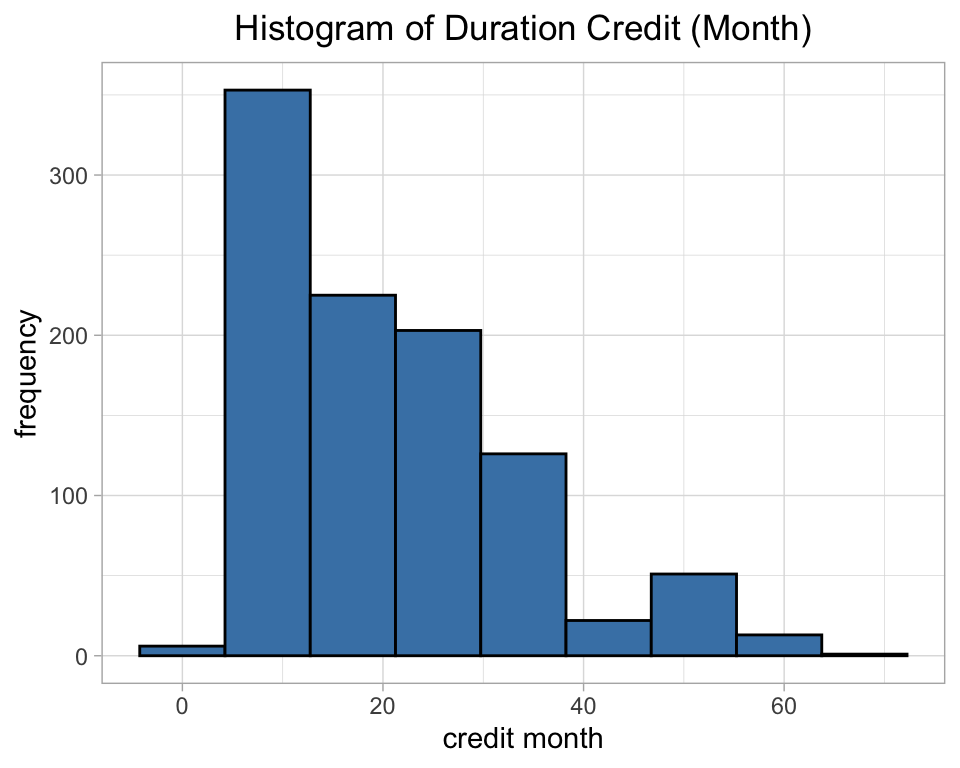

```r
ggplot(data = clean_df, aes(Duration.of.Credit..month.)) +
  geom_histogram(col = "black",fill ="steelblue", bins = 9) +
  theme_light() +
  ggtitle("Histogram of Duration Credit (Month)") +
  theme(plot.title = element_text(hjust = 0.5)) +
  ylab("frequency") +
  xlab("credit month")
```

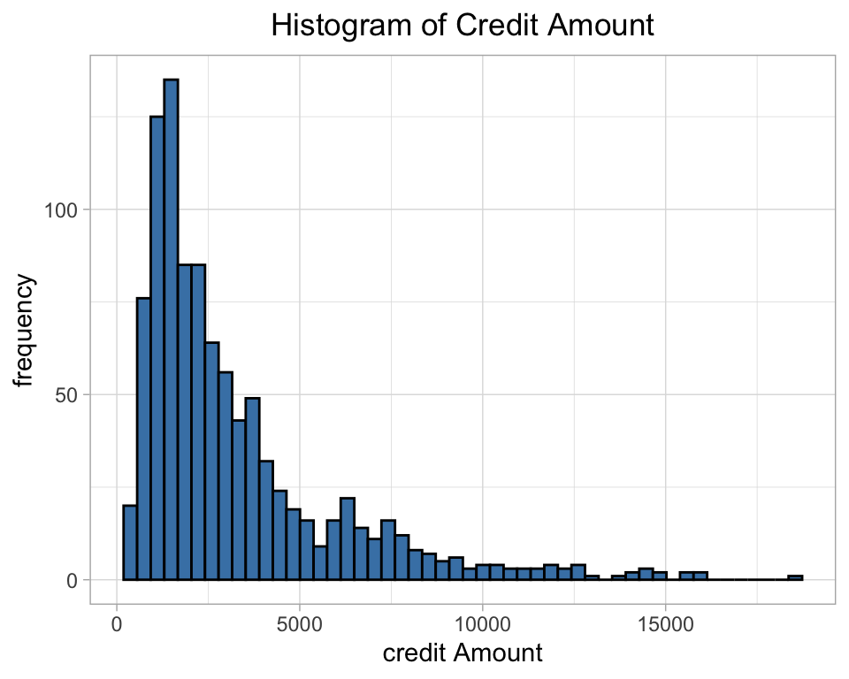

```r
ggplot(data = clean_df, aes(Credit.Amount)) +
  geom_histogram(col = "black",fill ="steelblue", bins = 50) +
  theme_light() +
  ggtitle("Histogram of Credit Amount") +
  theme(plot.title = element_text(hjust = 0.5)) +
  ylab("frequency") +
  xlab("credit Amount")
```

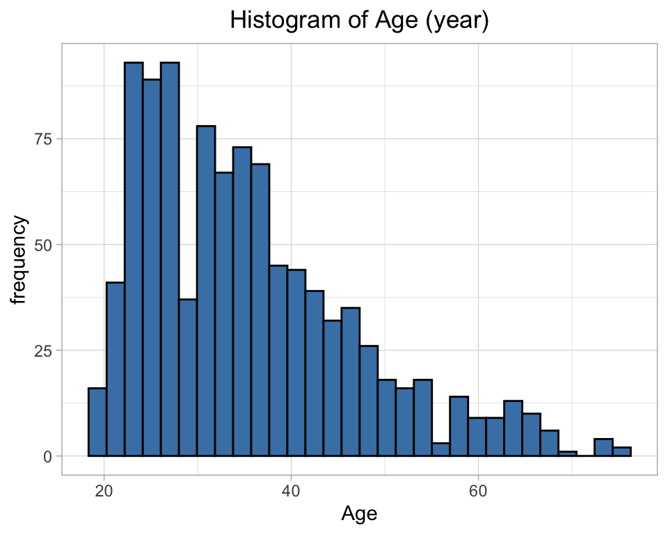

```r
ggplot(data = clean_df, aes(Age..years.)) +
  geom_histogram(col = "black",fill ="steelblue", bins = 30) +
  theme_light() +
  ggtitle("Histogram of Age (year)") +
  theme(plot.title = element_text(hjust = 0.5)) +
  ylab("frequency") +
  xlab("Age")
```

Box-Plot of continuous variables:

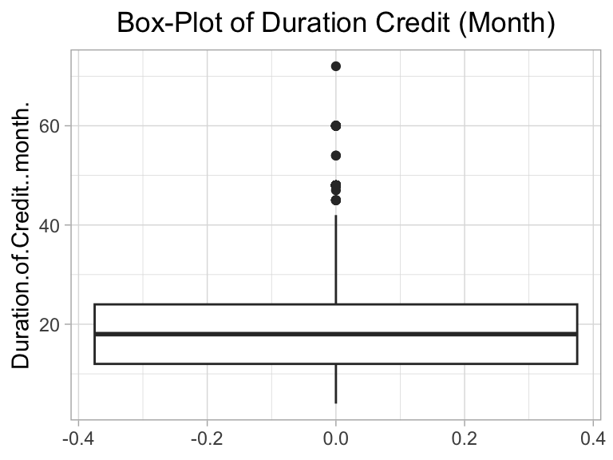

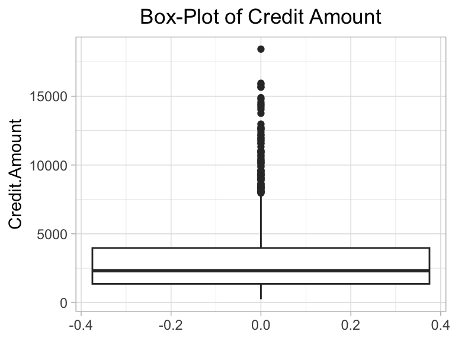

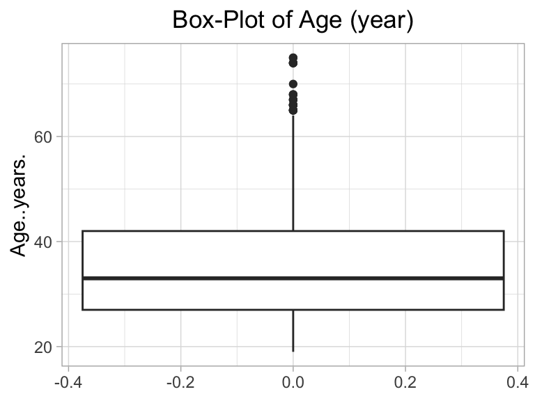

```
## # A tibble: 2 × 5
##   Creditability AVG_DurationCredit_Month AVG_CreditAmount AVG_Age_Year     n
##           <int>                    <dbl>            <dbl>        <dbl> <int>
## 1             0                     24.9            3938.         34.0   300
## 2             1                     19.2            2985.         36.2   700
```

$$\\[0.35in]$$

Heatmap of Correlation between variables :

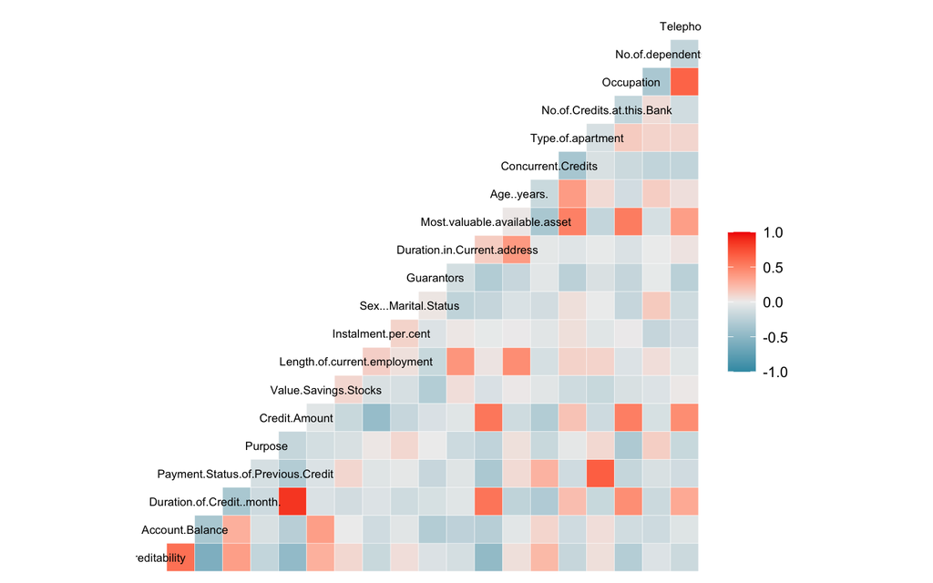

```r
# Heatmap of Correlation Between Variables
library(GGally)
ggcorr(cor(clean_df[,c(1:20)]),
       label = FALSE,
       label_round = 2,
       label_alpha = TRUE,
       size = 2.5,
       hjust = 0.45)
```

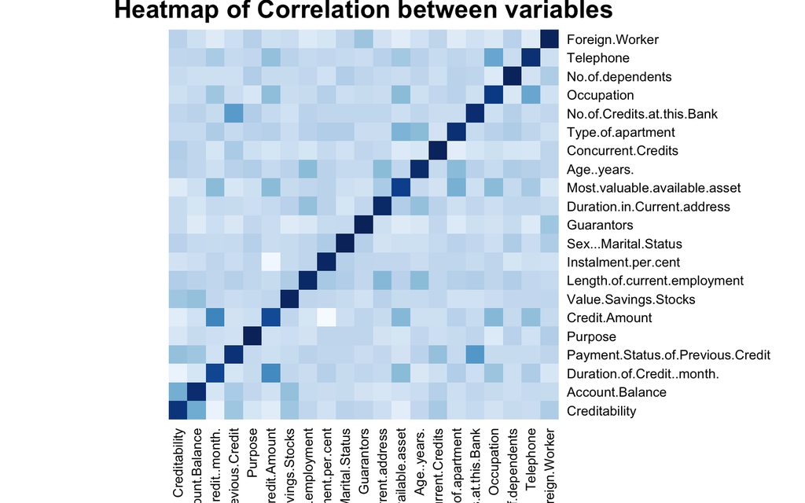

```r
library(RColorBrewer)
heatmap(cor(clean_df[,c(1:21)]), Colv = NA, Rowv = NA,
        main = "Heatmap of Correlation between variables", scale = "column",
        col = colorRampPalette(brewer.pal(9,"Blues"))(100))
```

$$\\[0.35in]$$

Chi-square Test between Creditability and Discrete Variables

```r
# Chi-square Test between Creditability and Discrete Variables
chi_1 <- chisq.test(Creditability, Account.Balance)
chi_2 <- chisq.test(Creditability, Payment.Status.of.Previous.Credit)
chi_3 <- chisq.test(Creditability, Purpose)
chi_4 <- chisq.test(Creditability, Value.Savings.Stocks)
chi_5 <- chisq.test(Creditability, Length.of.current.employment)
chi_6 <- chisq.test(Creditability, Instalment.per.cent)
chi_7 <- chisq.test(Creditability, Sex...Marital.Status)
chi_8 <- chisq.test(Creditability, Guarantors)
chi_9 <- chisq.test(Creditability, Duration.in.Current.address)
chi_10 <- chisq.test(Creditability, Most.valuable.available.asset)
chi_11 <- chisq.test(Creditability, Concurrent.Credits)
chi_12 <- chisq.test(Creditability, Type.of.apartment  )
chi_13 <- chisq.test(Creditability, No.of.Credits.at.this.Bank)
chi_14 <- chisq.test(Creditability,  Occupation )
chi_15 <- chisq.test(Creditability, No.of.dependents )
chi_16 <- chisq.test(Creditability, Telephone)
chi_17 <- chisq.test(Creditability, Foreign.Worker)
```

```
## [[1]]
##  Chi_square_1  Chi_square_2  Chi_square_3  Chi_square_4  Chi_square_5
##  1.218902e-26  1.279187e-12  1.157491e-04  2.761214e-07  1.045452e-03
##  Chi_square_6  Chi_square_7  Chi_square_8  Chi_square_9 Chi_square_10
##  1.400333e-01  2.223801e-02  3.605595e-02  8.615521e-01  2.858442e-05
## Chi_square_11 Chi_square_12 Chi_square_13 Chi_square_14 Chi_square_15
##  1.629318e-03  8.810311e-05  4.451441e-01  5.965816e-01  1.000000e+00
## Chi_square_16 Chi_square_17
##  2.788762e-01  1.583075e-02
```

for continuous variables, use T-Test for 2 Group of Creditability :

```r
## p-value t-test between Creditability and Continuous Variables
data_t_test_1 <- clean_df %>%
  filter(Creditability == 1)
data_t_test_0 <- clean_df %>%
  filter(Creditability == 0)

t_1 <- t.test(data_t_test_0$Duration.of.Credit..month.,
              data_t_test_1$Duration.of.Credit..month.)

t_2 <- t.test(data_t_test_0$Age..years.,
              data_t_test_1$Age..years.)

t_3 <- t.test(data_t_test_0$Credit.Amount,
              data_t_test_1$Credit.Amount)

t_1
```

```
##
##  Welch Two Sample t-test
##
## data:  data_t_test_0$Duration.of.Credit..month. and data_t_test_1$Duration.of.Credit..month.
## t = 6.4696, df = 485.44, p-value = 2.404e-10
## alternative hypothesis: true difference in means is not equal to 0
## 95 percent confidence interval:
##  3.936033 7.369682
## sample estimates:
## mean of x mean of y
##  24.86000  19.20714
```

```r
t_2
```

```
##
##  Welch Two Sample t-test
##
## data:  data_t_test_0$Age..years. and data_t_test_1$Age..years.
## t = -2.9081, df = 571.37, p-value = 0.003778
## alternative hypothesis: true difference in means is not equal to 0
## 95 percent confidence interval:
##  -3.7864239 -0.7335761
## sample estimates:
## mean of x mean of y
##     33.96     36.22
```

```r
t_3
```

```
##
##  Welch Two Sample t-test
##
## data:  data_t_test_0$Credit.Amount and data_t_test_1$Credit.Amount
## t = 4.2643, df = 421.86, p-value = 2.477e-05
## alternative hypothesis: true difference in means is not equal to 0
## 95 percent confidence interval:
##   513.5476 1391.8201
## sample estimates:
## mean of x mean of y
##  3938.127  2985.443
```

$$\\[0.05in]$$

##### Variables that use in Models

- Account.Balance
- Payment.Status.of.Previous.Credit
- Purpose
- Value.Savings.Stocks
- Length.of.current.employment
- Sex…Marital.Status
- Type.of.apartment
- Most.valuable.available.asset
- Concurrent.Credits
- Age..years.
- Duration.of.Credit..month.
- Credit.Amount

$$\\[0.35in]$$

#### Prepare Data for Training

Setting the factor Before training the binary classification models

```r
clean_df$Creditability <- factor(clean_df$Creditability,
                                 levels = c(0,1),
                                 labels = c("Bad", "Good"))
clean_df$Creditability <- as.ordered(clean_df$Creditability)
```

Create function to Split Data for use in Training Models and Validation Models

```r
# Split data

split_data <- function(data, p) {
  set.seed(444)
  n <- nrow(data)
  id <- sample(1:n, size = n*p)
  train_df <- data[id, ]
  test_df <- data[-id, ]
  return(list(train_df = train_df, test_df = test_df))
}

split_credit <- split_data(clean_df, 0.7)
train_df <- split_credit$train_df
test_df <- split_credit$test_df
```

split data train_df and test_df with probabilty = 0.7 for train data and probability = 0.3 for test data
$$\\[1in]$$

## III. Train/ Evaluate Models

And then before train model, I have set the train Control which mean the resampling method. For all models, I use the K-fold Cross Valoidation instead Bootstrap the set as default in caret train function.

```r
#set the resamples method
# use K-fold Cross validation
ctrl_cv <- trainControl(method = "cv",
                        number = 5,
                        verboseIter = TRUE)
```

#### Logistic Regression

```r
#1. Logistic Regression
glm_m1 <- train(Creditability~
                 Account.Balance +
                 Payment.Status.of.Previous.Credit +
                 Purpose +
                 Value.Savings.Stocks +
                 Length.of.current.employment +
                 Sex...Marital.Status +
                 Type.of.apartment +
                 Most.valuable.available.asset +
                 Concurrent.Credits +
                 Age..years.+
                 Duration.of.Credit..month. +
                 Credit.Amount,
               data = train_df,
               method = "glm",
               trControl = ctrl_cv)
glm_m1
```

```
## Generalized Linear Model
##
## 700 samples
##  12 predictor
##   2 classes: 'Bad', 'Good'
##
## No pre-processing
## Resampling: Cross-Validated (5 fold)
## Summary of sample sizes: 559, 560, 560, 561, 560
## Resampling results:
##
##   Accuracy   Kappa
##   0.7685257  0.4147772
```

```r
varImp(glm_m1)
```

```
## glm variable importance
##
##                                   Overall
## Account.Balance                    100.00
## Payment.Status.of.Previous.Credit   53.15
## Value.Savings.Stocks                53.15
## Duration.of.Credit..month.          47.50
## Purpose                             47.13
## Most.valuable.available.asset       34.31
## Sex...Marital.Status                22.12
## Type.of.apartment                   21.09
## Length.of.current.employment        19.84
## Age..years.                         17.24
## Concurrent.Credits                  12.81
## Credit.Amount                        0.00
```

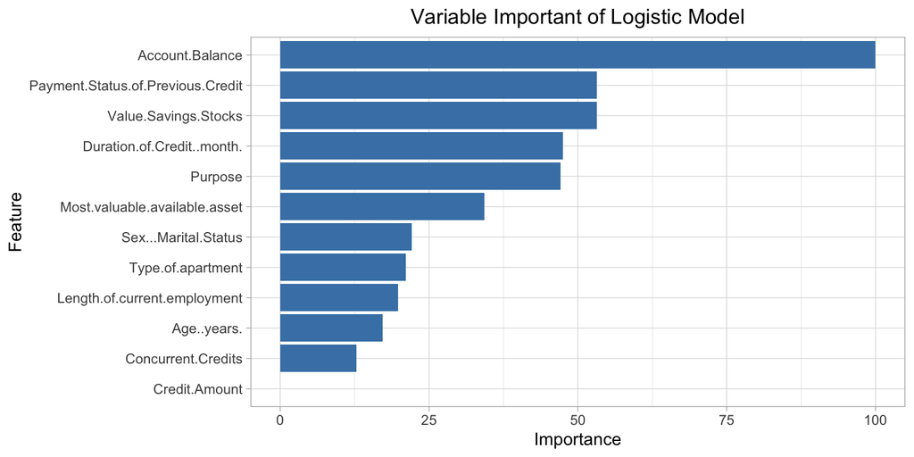

```r
ggplot(varImp(glm_m1)) +
  geom_col(fill = "steelblue") +
  theme_light() +
  ggtitle("Variable Important of Logistic Model") +
  theme(plot.title = element_text(hjust = 0.5))
```

```r
# predict newdataset with Test_df
p_glm <- predict(glm_m1, newdata = test_df)
```

Confusion Matrix:

```r
confusionMatrix(test_df$Creditability, p_glm,
                positive = "Good")
```

```
## Confusion Matrix and Statistics
##
##           Reference
## Prediction Bad Good
##       Bad   36   46
##       Good  28  190
##
##                Accuracy : 0.7533
##                  95% CI : (0.7005, 0.8011)
##     No Information Rate : 0.7867
##     P-Value [Acc > NIR] : 0.92859
##
##                   Kappa : 0.3334
##
##  Mcnemar's Test P-Value : 0.04813
##
##             Sensitivity : 0.8051
##             Specificity : 0.5625
##          Pos Pred Value : 0.8716
##          Neg Pred Value : 0.4390
##              Prevalence : 0.7867
##          Detection Rate : 0.6333
##    Detection Prevalence : 0.7267
##       Balanced Accuracy : 0.6838
##
##        'Positive' Class : Good
##
```

from confusion matrix the Accuracy of model with test_df near the Accuracy from train_df which mean model are goodfit.

```r
#ROC-AUC
library(pROC)
roc_glm <- roc(test_df$Creditability, p_glm)
auc_glm <- round(auc(test_df$Creditability, p_glm),4)
```

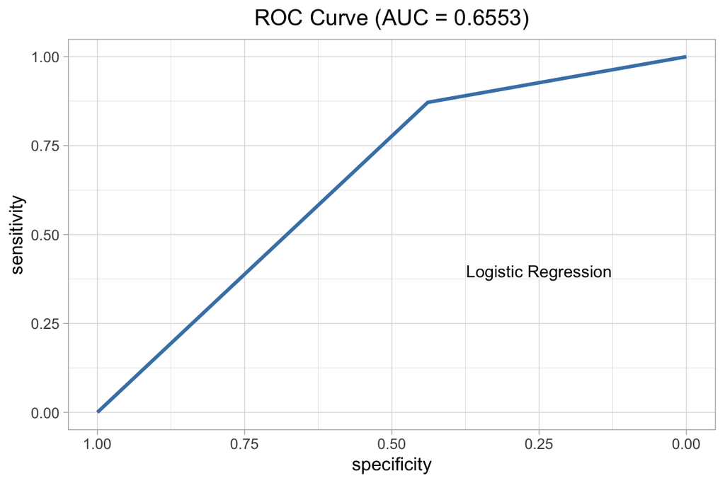

```r
ggroc(roc_glm, col = "steelblue", size = 1) +
  ggtitle(paste0('ROC Curve (AUC = ',auc_glm, ')')) +
  theme_light() +
  theme(plot.title = element_text(hjust = 0.5)) +
   annotate("text", x = 0.25, y = 0.38, vjust = 0, size = 3.5,
           label = paste0("Logistic Regression"))
```

Plot of ROC curve of Logistic Regression model and AUC = 0.6553

$$\\[0.5in]$$

#### Decision Tree

Applying Decision tree Method :

```r
tree_m <- train(Creditability~
                  Account.Balance +
                  Payment.Status.of.Previous.Credit +
                  Purpose +
                  Value.Savings.Stocks +
                  Length.of.current.employment +
                  Sex...Marital.Status +
                  Type.of.apartment +
                  Most.valuable.available.asset +
                  Concurrent.Credits +
                  Age..years.+
                  Duration.of.Credit..month. +
                  Credit.Amount,
                data = train_df,
                method = "rpart",
                tuneGrid = expand.grid(cp = seq(0.02, 0.03, length = 10)),
                trControl = ctrl_cv)
tree_m
```

```
## CART
##
## 700 samples
##  12 predictor
##   2 classes: 'Bad', 'Good'
##
## No pre-processing
## Resampling: Cross-Validated (5 fold)
## Summary of sample sizes: 560, 561, 560, 560, 559
## Resampling results across tuning parameters:
##
##   cp          Accuracy   Kappa
##   0.02000000  0.7272082  0.3207742
##   0.02111111  0.7214940  0.3233920
##   0.02222222  0.7214940  0.3233920
##   0.02333333  0.7257493  0.3268956
##   0.02444444  0.7257493  0.3268956
##   0.02555556  0.7257493  0.3268956
##   0.02666667  0.7243104  0.3196280
##   0.02777778  0.7243104  0.3196280
##   0.02888889  0.7243104  0.3196280
##   0.03000000  0.7243104  0.3196280
##
## Accuracy was used to select the optimal model using the largest value.
## The final value used for the model was cp = 0.02.
```

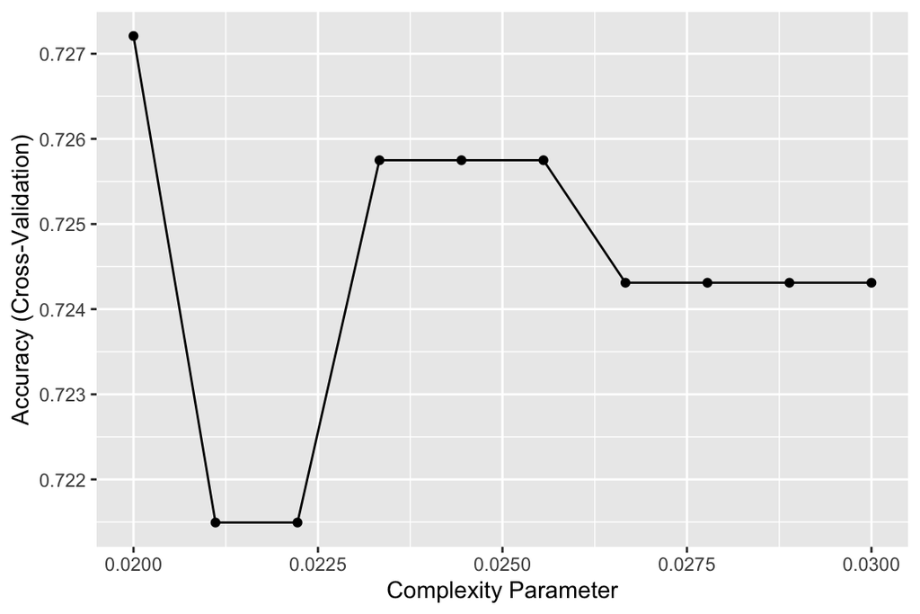

```r
ggplot(tree_m)
```

In decision tree Methods have a Tuning Parameter name cp, after training tree model the best tune of cp is in between length 0.02 - 0.03

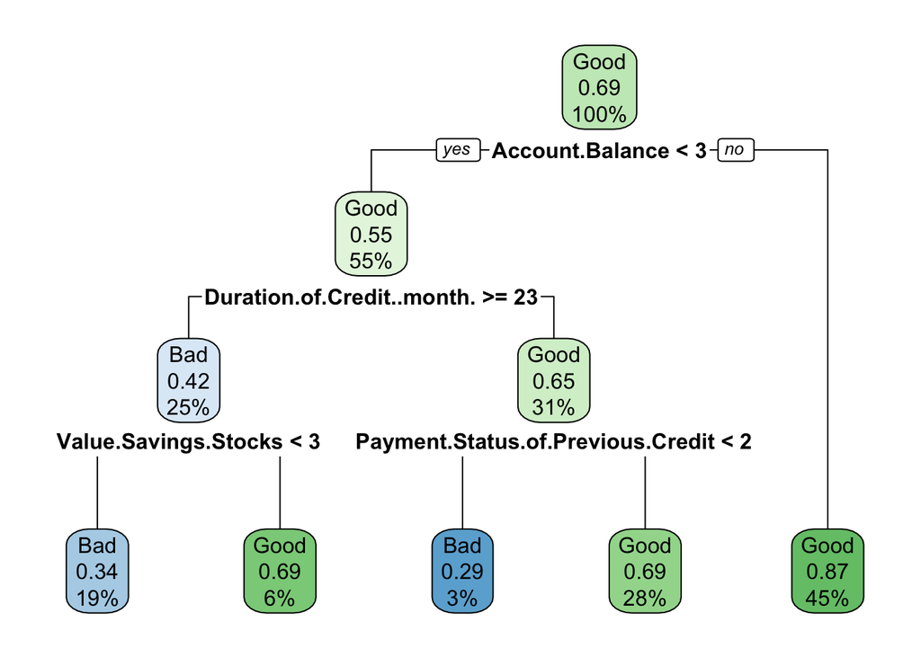

```r
library(rpart.plot)
rpart.plot(tree_m$finalModel)
```

plot of decision tree method

$$\\[0.1in]$$

```r
varImp(tree_m)
```

```
## rpart variable importance
##
##                                   Overall
## Account.Balance                   100.000
## Value.Savings.Stocks               91.618
## Payment.Status.of.Previous.Credit  85.843
## Duration.of.Credit..month.         72.102
## Credit.Amount                      51.085
## Most.valuable.available.asset      30.195
## Purpose                             5.628
## Sex...Marital.Status                0.000
## Age..years.                         0.000
## Concurrent.Credits                  0.000
## Length.of.current.employment        0.000
## Type.of.apartment                   0.000
```

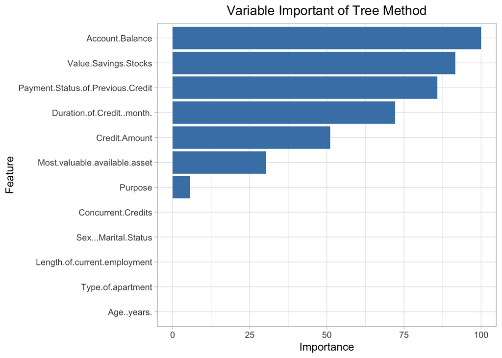

```r
ggplot(varImp(tree_m)) +
  geom_col(fill = "steelblue") +
  theme_light() +
  ggtitle("Variable Important of Tree Method") +
  theme(plot.title = element_text(hjust = 0.5))
```

```r
p_tree <- predict(tree_m, newdata = test_df)

confusionMatrix(test_df$Creditability, p_tree,
                positive = "Good")
```

```
## Confusion Matrix and Statistics
##
##           Reference
## Prediction Bad Good
##       Bad   35   47
##       Good  26  192
##
##                Accuracy : 0.7567
##                  95% CI : (0.704, 0.8041)
##     No Information Rate : 0.7967
##     P-Value [Acc > NIR] : 0.96122
##
##                   Kappa : 0.3343
##
##  Mcnemar's Test P-Value : 0.01924
##
##             Sensitivity : 0.8033
##             Specificity : 0.5738
##          Pos Pred Value : 0.8807
##          Neg Pred Value : 0.4268
##              Prevalence : 0.7967
##          Detection Rate : 0.6400
##    Detection Prevalence : 0.7267
##       Balanced Accuracy : 0.6886
##
##        'Positive' Class : Good
##
```

from confusion matrix the Accuracy of model with test_df is 75%.

```r
#ROC-AUC
roc_tree <- roc(test_df$Creditability, p_tree)
auc_tree <- round(auc(test_df$Creditability, p_tree),4)
```

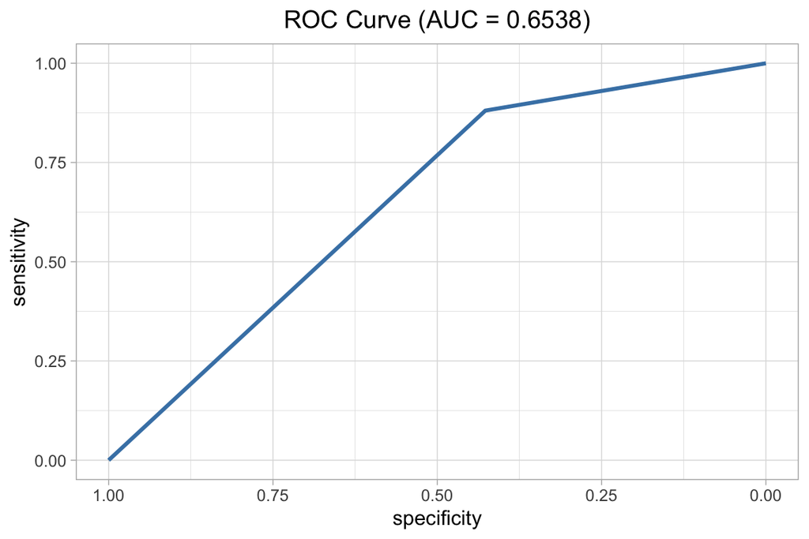

```r
ggroc(roc_tree, col = "steelblue", size = 1) +
  ggtitle(paste0('ROC Curve (AUC = ',auc_tree, ')')) +
  theme_light() +
  theme(plot.title = element_text(hjust = 0.5))
```

$$\\[0.5in]$$

#### Random Forest

Try another method, Random Forest:

```r
#3. Random Forest
rf_m <- train(Creditability~
                Account.Balance +
                Payment.Status.of.Previous.Credit +
                Purpose +
                Value.Savings.Stocks +
                Length.of.current.employment +
                Sex...Marital.Status +
                Type.of.apartment +
                Most.valuable.available.asset +
                Concurrent.Credits +
                Age..years.+
                Duration.of.Credit..month. +
                Credit.Amount,
              data = train_df,
              tuneLength = 11,
              method = "rf",
              trControl = ctrl_cv)
rf_m
```

```
## Random Forest
##
## 700 samples
##  12 predictor
##   2 classes: 'Bad', 'Good'
##
## No pre-processing
## Resampling: Cross-Validated (5 fold)
## Summary of sample sizes: 560, 560, 560, 560, 560
## Resampling results across tuning parameters:
##
##   mtry  Accuracy   Kappa
##    2    0.7528571  0.3664681
##    3    0.7400000  0.3407085
##    4    0.7442857  0.3652317
##    5    0.7457143  0.3737164
##    6    0.7428571  0.3742522
##    7    0.7385714  0.3606911
##    8    0.7542857  0.3971247
##    9    0.7514286  0.4005326
##   10    0.7471429  0.3850451
##   11    0.7400000  0.3682977
##   12    0.7357143  0.3609703
##
## Accuracy was used to select the optimal model using the largest value.
## The final value used for the model was mtry = 8.
```

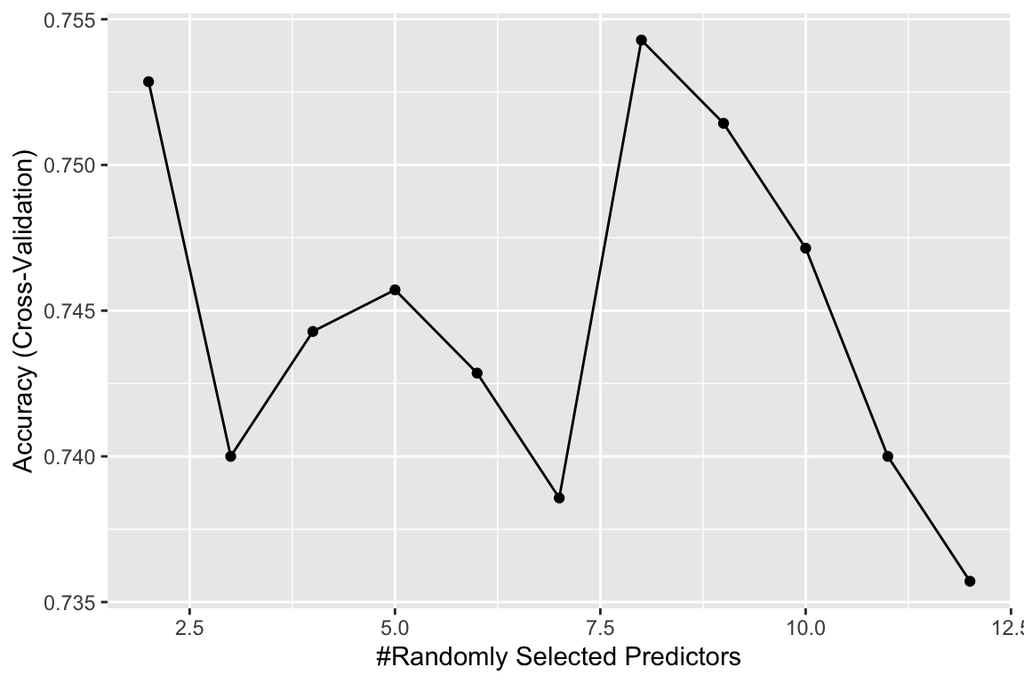

```r
ggplot(rf_m)
```

mtry is a Tuning Parameter of random forest method, this is a plot that showing the best tune of mtry

```r
p_rf <- predict(rf_m, newdata = test_df)

confusionMatrix(test_df$Creditability, p_rf,
                positive = "Good")
```

```
## Confusion Matrix and Statistics
##
##           Reference
## Prediction Bad Good
##       Bad   43   39
##       Good  34  184
##
##                Accuracy : 0.7567
##                  95% CI : (0.704, 0.8041)
##     No Information Rate : 0.7433
##     P-Value [Acc > NIR] : 0.3249
##
##                   Kappa : 0.3756
##
##  Mcnemar's Test P-Value : 0.6397
##
##             Sensitivity : 0.8251
##             Specificity : 0.5584
##          Pos Pred Value : 0.8440
##          Neg Pred Value : 0.5244
##              Prevalence : 0.7433
##          Detection Rate : 0.6133
##    Detection Prevalence : 0.7267
##       Balanced Accuracy : 0.6918
##
##        'Positive' Class : Good
##
```

from confusion matrix the Accuracy of model with test_df is 75%.

```r
#ROC-AUC
roc_rf <- roc(test_df$Creditability, p_rf)
auc_rf <- round(auc(test_df$Creditability, p_rf),4)
```

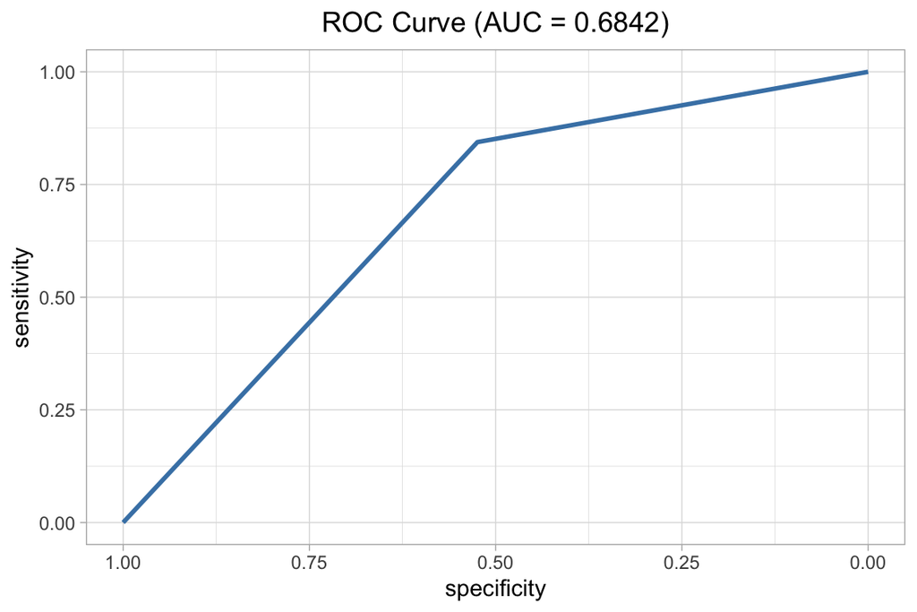

```r
ggroc(roc_rf, col = "steelblue", size = 1) +
  ggtitle(paste0('ROC Curve (AUC = ',auc_rf, ')')) +
  theme_light() +
  theme(plot.title = element_text(hjust = 0.5))
```

$$\\[0.35in]$$

```r
##### Compare Models ######
list_m <- list(logistic = glm_m1,
               DecisionTree = tree_m,
               RamdomForest = rf_m)


result <- resamples(list_m)

summary(result)
```

```
##
## Call:
## summary.resamples(object = result)
##
## Models: logistic, DecisionTree, RamdomForest
## Number of resamples: 5
##
## Accuracy
##                   Min.   1st Qu.    Median      Mean   3rd Qu.      Max. NA's
## logistic     0.7410072 0.7500000 0.7714286 0.7685257 0.7730496 0.8071429    0
## DecisionTree 0.6808511 0.7214286 0.7266187 0.7272082 0.7428571 0.7642857    0
## RamdomForest 0.7285714 0.7285714 0.7500000 0.7542857 0.7571429 0.8071429    0
##
## Kappa
##                   Min.   1st Qu.    Median      Mean   3rd Qu.      Max. NA's
## logistic     0.3433071 0.3859649 0.4036209 0.4147772 0.4288608 0.5121322    0
## DecisionTree 0.2328618 0.2659811 0.3049898 0.3207742 0.3642785 0.4357596    0
## RamdomForest 0.3200409 0.3586387 0.3783594 0.3971247 0.4149459 0.5136387    0
```

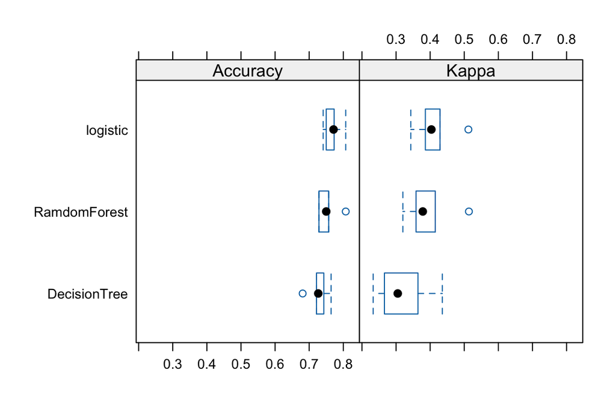

```r
bwplot(result)
```

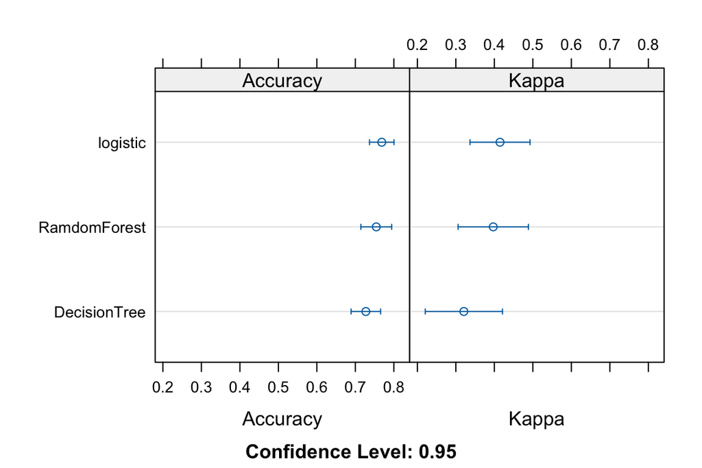

```r
dotplot(result)
```

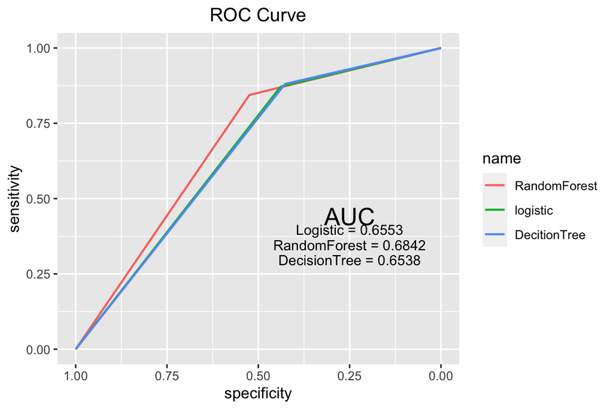

```r
# plot Multiple ROC Curve and AUC
ggroc(list(RandomForest = roc_rf,
           logistic = roc_glm,
           DecitionTree = roc_tree),
      size = 0.7)  +
  theme(plot.title = element_text(hjust = 0.5)) +
  ggtitle(paste0("ROC Curve")) +
  annotate("text", x = 0.25, y = 0.43, vjust = 0.3, size = 6,
           label = "AUC") +
  annotate("text", x = 0.25, y = 0.33, vjust = 0, size = 3.5,
           label = paste0("RandomForest = ", auc_rf)) +
  annotate("text", x = 0.25, y = 0.38, vjust = 0, size = 3.5,
           label = paste0("Logistic = ", auc_glm)) +
  annotate("text", x = 0.25, y = 0.28, vjust = 0, size = 3.5,
           label = paste0("DecisionTree = ", auc_tree))
```

$$\\[0.1in]$$

#### Summary

Accuracy and AUC are measures to evaluate the goodness of model performance. But due to our dataset the Creditability are imbalance, the proportion of Good = 0.7 and Bad = 0.3. In this case AUC is good choice, because AUC is well-suited for imbalanced datasets.According to this reason, Random Forest have the maximum AUC.